# Communicate Data Findings for PISA 2012

## by David Lassig

## Investigation Overview

This dataset shows the effort of the OECD giving reasonable test results to argue about academic performance of school children in dependency to many different factors. Everyone that has children knows this predicament. We want our kids to be very sucessful in their later lives but we don't want to leverage them to be more hardworking and disciplined as it could harm their emotional condition. The evaluation of this dataset could point out the right advice to give our kids the right settings for beeing happy and sucessful in their schooldays and their whole life at all. I will pick up some of the factors and show several coherences between them.

## Dataset Overview

This dataset is huge as it holds **485490** rows by using **636** different columns for several tests. It includes results from questionaires regarding:

- home environment of students
- parental environment of students
- condition of the school
- the habits and practices of the teacher
- test results from science-oriented tests
- self-perception of the students

Therefore it's crucial to cut only a few interesting columns from this dataset. I've used this [document](http://www.oecd.org/pisa/pisaproducts/PISA12_stu_codebook.pdf) to get a explanation for the partly cryptic column names. It's one of the codebooks next to some others that are exclusively designed for the purpose to explain the different columns.

## Preparation of the Data

I did some steps to prepare the data for visualisation:

- summarize multiple categorical columns into one numeric variable
- creating subsets
- regrouping and filtering for specific categoric values

## Correlation of Main Features

To get a fast overview of the relations between my choosen main features I'm using a correlation matrix heatmap to easily point out:

- there isn't any really strong correlation between a pair of variables
- the Practices of Teachers influences the **Interest and Motivation for Math** but **NOT** the **Self-Efficacy and Familiarity with Math**
- the **Interest in Math** influences the **Math Self-Efficacy** but **NOT** the **Familiarity with Math**
- **Wealth** doesn't affect any variable at all

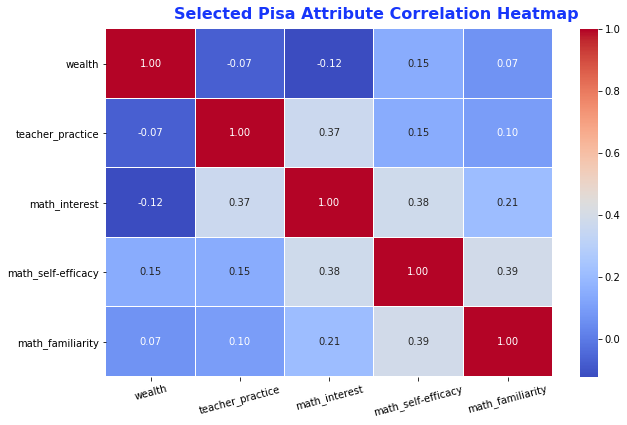

```python
pisa_visual_df.corr()
# Correlation Matrix Heatmap
f, ax = plt.subplots(figsize=(10, 6))
corr = pisa_visual_df.corr()
hm = sb.heatmap(round(corr,2), annot=True, ax=ax, cmap="coolwarm",fmt='.2f',
                 linewidths=.05)
f.subplots_adjust(top=0.93)
plt.xticks(rotation=15)
t= f.suptitle('Selected Pisa Attribute Correlation Heatmap', color="#1736fa",fontsize=16, fontweight='bold')
```

## Heatmap for showing Math Familiarity categorized by Nation

As many different nations did participate in the PISA studies it's interesting to see the Math Familiarity over multiple different countries. I'm using a customized heatmap to show this relationship. It results in:

- very big differences between several countries
- **swedish** students did perform **really bad** in terms of **Math Familiarity**
- **chinese** students did perform **really well** in terms of **Math Familiarity**

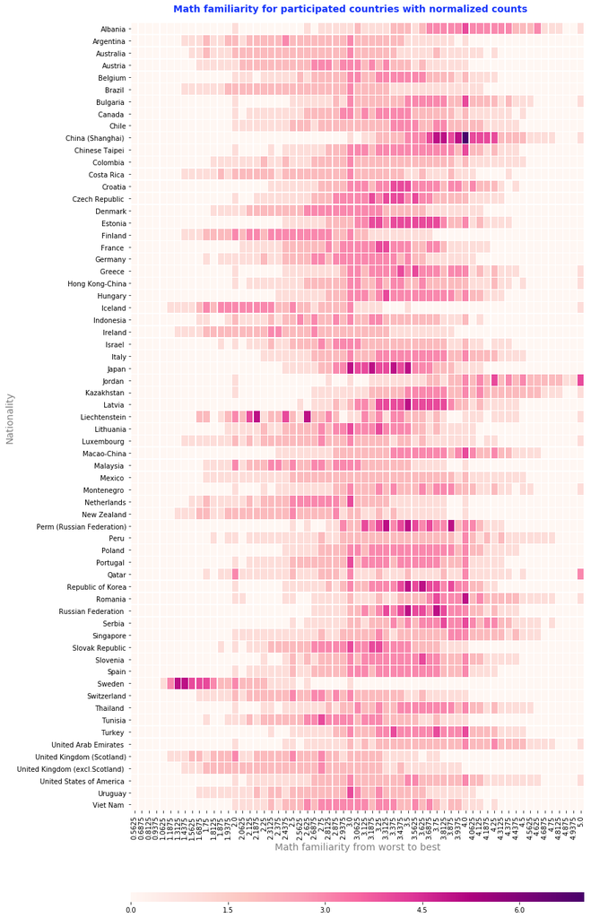

```python
def df_row_normalize(dataframe):
    '''Normalizes the values of a given pandas.Dataframe by the total sum of each line.
    Algorithm based on https://stackoverflow.com/questions/26537878/pandas-sum-across-columns-and-divide-each-cell-from-that-value'''
    return dataframe.div(dataframe.sum(axis=1), axis=0)

pisa_nationality = pisa_visual_df.groupby(by=['nationality'])['math_familiarity'].value_counts().sort_index()
pisa_nationality = pisa_nationality.unstack(1)
pisa_nationality.fillna(value=0, inplace=True)
pisa_nationality = df_row_normalize(pisa_nationality)
pisa_nationality = (pisa_nationality*100).astype('int64')
pisa_nationality.drop(columns=[0.625,0.75,0.875,1.0,1.125,1.25,1.375,1.5,1.625],inplace=True)

fig3, ax = plt.subplots(figsize=(12, 25))
fig3.subplots_adjust(top=.965)
plt.suptitle('Math familiarity for participated countries with normalized counts', color="#1736fa",fontsize=14, fontweight='bold')

cbar_kws = {'orientation':"horizontal", 'pad':0.08, 'aspect':50}
sb.heatmap(pisa_nationality, annot=False, fmt='d', linewidths=.3, ax=ax, cmap='RdPu', cbar_kws=cbar_kws);
plt.xlabel("Math familiarity from worst to best", color="grey", fontsize=14)
plt.ylabel("Nationality", color="grey", fontsize=14);
```

## Scatterplot to show Influence of Mothers Job on Wealth and Math Familiarity

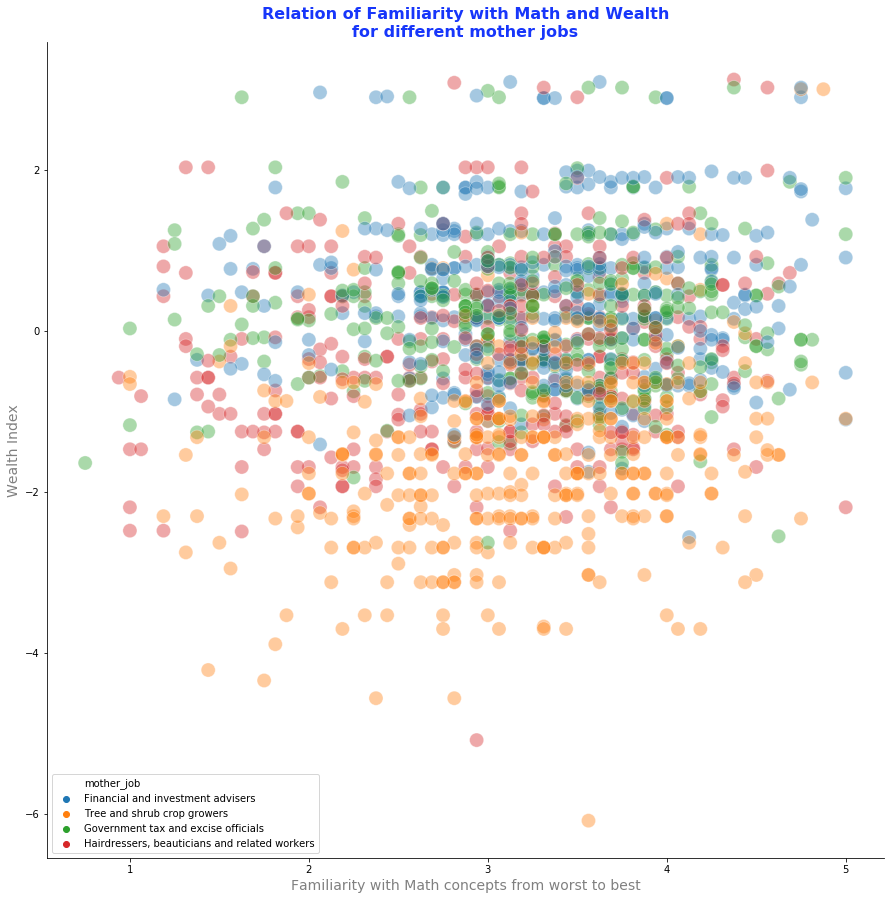

```python
pisa_grid_df = pisa_visual_df.copy()

final_job_categories = []
mjobs_under_600 = [x for x,y in list(pisa_visual_df['mother_job'].value_counts().iteritems()) if y < 600][2:]
for job in mjobs_under_600:
    if job.startswith("Financial and investment advisers"):
        final_job_categories.append(job)
    if job.startswith("Government tax and excise officials"):
        final_job_categories.append(job)
    if job.startswith("Tree and shrub crop growers"):
        final_job_categories.append(job)
    if job.startswith("Hairdressers, beauticians and related workers"):
        final_job_categories.append(job)


pisa_grid_df['mother_job'] = pisa_visual_df['mother_job'].astype('category', ordered = True,
                                                         categories = final_job_categories);

plt.figure(figsize=[15,15])
sb.scatterplot(data=pisa_grid_df,x="math_familiarity",y="wealth",hue="mother_job", alpha=.4, s=200);
plt.title("Relation of Familiarity with Math and Wealth\nfor different mother jobs", color="#1736fa",fontsize=16, fontweight='bold');
plt.ylabel("Wealth Index", color="grey", fontsize=14)
plt.xlabel("Familiarity with Math concepts from worst to best", color="grey", fontsize=14);
ax = plt.gca()
ax.spines['right'].set_visible(False)
ax.spines['top'].set_visible(False)
```

## Final Words

I'm glad that Wealth has only a small influence on the mathematical achievements of a student as it's a variable that is very uneven distributed in the world.

Otherwise it depends strongly on the nation you're born into, whether a student is prone to strong mathematical performance.